# Práctica PE-U4 — Apache Spark

**Equipo C**  
**Dominio seleccionado:** FUVV – Laboratorios Informáticos

Este dominio puede producir grandes volúmenes de datos porque cada reserva, cambio de estado, franja horaria, laboratorio, materia, docente y participante genera eventos que se acumulan durante varios periodos lectivos. Se utiliza un dataset sintético y reproducible porque no existen 500 000 registros operacionales públicos adecuados para realizar esta comparación con el volumen exigido. Además, trabajar con datos generados mediante la semilla fija `20260804` permite repetir el experimento bajo las mismas condiciones, validar la integridad del conjunto y evitar el uso de información personal real de estudiantes, docentes o responsables de reservas. Los datos no representan operaciones reales de la UTEQ. El pipeline podría apoyar decisiones del sistema como distribuir la demanda entre laboratorios, anticipar franjas de alta ocupación y priorizar solicitudes según capacidad, duración y disponibilidad, sin exponer datos personales ni atribuir los resultados sintéticos a usuarios reales.

## 1. Entorno de ejecución

La ejecución usa PySpark 3.5.0 sobre Spark Standalone con cuatro procesos executor independientes de un core. Las versiones y la configuración mostradas a continuación se consultan desde el entorno realmente ejecutado.

```python
import gc
import platform
import subprocess
import sys
from pathlib import Path

import pandas as pd
import pyspark
from IPython.display import Image, display

ROOT = Path.cwd()
if ROOT.name == 'notebooks':
    ROOT = ROOT.parent
SRC = ROOT / 'src'
if str(SRC) not in sys.path:
    sys.path.insert(0, str(SRC))

print(f'Python: {sys.version.split()[0]}')
print(f'pandas: {pd.__version__}')
print(f'PySpark: {pyspark.__version__}')
java = subprocess.run(['java', '-version'], capture_output=True, text=True, check=False)
java_text = (java.stderr or java.stdout).splitlines()
print('Java:', java_text[0] if java_text else 'no disponible')
print(f'Plataforma: {platform.platform()}')
assert pyspark.__version__ == '3.5.0', f'PySpark inesperado: {pyspark.__version__}'
```

```
Python: 3.12.10
pandas: 2.3.3
PySpark: 3.5.0
Java: openjdk version "17.0.20" 2026-07-21
Plataforma: Windows-11-10.0.26200-SP0
```

## 2. Dataset sintético

El conjunto fue generado de forma determinista con la semilla fija `20260804`. Contiene exactamente **500 000 solicitudes** y **40 laboratorios**, relacionados 1:N mediante `laboratorio_id`. No contiene datos reales ni operacionales de la UTEQ.

```python
import carga_datos

solicitudes_pd = carga_datos.cargar_solicitudes_pandas()
laboratorios_pd = carga_datos.cargar_laboratorios_pandas()
print(f'Conteo pandas solicitudes: {len(solicitudes_pd):,}')
print(f'Conteo pandas laboratorios: {len(laboratorios_pd):,}')
print('Columnas pandas solicitudes:', solicitudes_pd.columns.tolist())
print('Columnas pandas laboratorios:', laboratorios_pd.columns.tolist())
print('\nTipos pandas solicitudes:')
print(solicitudes_pd.dtypes.to_string())
print('\nTipos pandas laboratorios:')
print(laboratorios_pd.dtypes.to_string())
display(solicitudes_pd.head(5))
display(laboratorios_pd.head(5))
```

```
Conteo pandas solicitudes: 500,000
Conteo pandas laboratorios: 40
Columnas pandas solicitudes: ['solicitud_id', 'solicitante_id', 'docente_id', 'laboratorio_id', 'materia_id', 'periodo_lectivo_id', 'fecha_reserva', 'hora_inicio', 'hora_fin', 'numero_participantes', 'motivo', 'estado', 'creada_en', 'actualizada_en']
Columnas pandas laboratorios: ['laboratorio_id', 'piso_id', 'codigo', 'nombre', 'capacidad', 'descripcion', 'estado', 'activo', 'creado_en', 'actualizado_en']

Tipos pandas solicitudes:
solicitud_id            string[python]
solicitante_id          string[python]
docente_id              string[python]
laboratorio_id          string[python]
materia_id              string[python]
periodo_lectivo_id      string[python]
fecha_reserva           string[python]
hora_inicio             string[python]
hora_fin                string[python]
numero_participantes             int64
motivo                  string[python]
estado                  string[python]
creada_en               string[python]
actualizada_en          string[python]

Tipos pandas laboratorios:
laboratorio_id    string[python]
piso_id           string[python]
codigo            string[python]
nombre            string[python]
capacidad                  int64
descripcion       string[python]
estado            string[python]
activo                   boolean
creado_en         string[python]
actualizado_en    string[python]
```

|  | solicitud_id | solicitante_id | docente_id | laboratorio_id | materia_id | periodo_lectivo_id | fecha_reserva | hora_inicio | hora_fin | numero_participantes | motivo | estado | creada_en | actualizada_en |
| --- | --- | --- | --- | --- | --- | --- | --- | --- | --- | --- | --- | --- | --- | --- |
| 0 | e6823c03-1bff-5d6f-8947-4081b02e7c42 | 4217a3bc-f507-535b-92c8-1ae9faf04795 | 4faac1d1-0f45-53df-93b2-1c1e7d0effe0 | 23c254ed-4635-5cec-baa9-656efa7fd130 | 2773cfe2-71d4-5457-afbb-d86d2d7c32bc | 9b66a5fb-3f5b-54c2-9f5f-5b1a169d6bf0 | 2024-05-27 | 17:30:00 | 19:30:00 | 26 | Práctica de redes y conectividad | APROBADA | 2024-05-24T14:24:00+00:00 | 2024-05-26T12:03:00+00:00 |
| 1 | a5b14b68-3f5f-5685-ad70-c28f6a77aa19 | c51e3e91-c311-5da6-803e-11982f7102b3 | df014f0d-4ebd-52b2-b359-a8f280496ace | f5e43a2a-032c-562e-837a-ff3c72abffb4 | 6a58ef55-ed0f-589a-95e7-e3fe235b13c9 | fe3f3a0e-80b9-5d13-9a7d-126f9f4b998b | 2025-01-26 | 10:30:00 | 11:30:00 | 8 | Actividad de investigación aplicada | APROBADA | 2025-01-21T08:05:00+00:00 | 2025-01-24T02:12:00+00:00 |
| 2 | 61021505-a9ff-5118-bf4a-a211af10dbcf | bfc40a62-eb9f-55b4-a28b-c8d940081e46 | 44e8369e-5a66-5094-96a1-ee1d63c883f2 | ef815f08-b586-5f03-964a-a08004eaebf3 | f55333b4-10ca-5ed3-aed4-e7d764b80619 | 222bf413-7fe4-5b8e-9a64-79156ab493af | 2025-10-06 | 09:30:00 | 11:30:00 | 15 | Clase práctica de programación | RECHAZADA | 2025-08-08T00:33:00+00:00 | 2025-08-12T02:48:00+00:00 |
| 3 | 8802b18b-4bee-54a7-9c21-1dbbab3148d3 | 8c015158-0b80-5d42-8ce9-c139a830454d | 59f2f66e-1624-52c5-ab77-5eedb4421c9a | 2574a671-d58d-5db3-8c9f-2518d8a8d790 | c1794ff3-8715-51f7-b9b2-3009ceefa839 | 9b66a5fb-3f5b-54c2-9f5f-5b1a169d6bf0 | 2024-01-13 | 15:00:00 | 18:00:00 | 8 | Proyecto académico de desarrollo de software | APROBADA | 2023-12-29T05:29:00+00:00 | 2024-01-02T21:35:00+00:00 |
| 4 | c5a954af-6e0a-5a82-a0f7-56aafa126bd8 | bcff527c-5aa5-592b-9721-ee06a778da33 | 5b94695a-ab46-5174-a9e8-f6ee9b41dc7a | edd16813-3734-5d64-94e4-96368eeaa7e8 | 15093f8f-f8aa-5398-b04f-daa0d991a235 | 222bf413-7fe4-5b8e-9a64-79156ab493af | 2025-11-14 | 09:30:00 | 10:30:00 | 14 | Clase práctica de programación | PENDIENTE | 2025-09-05T01:45:00+00:00 | 2025-09-06T14:29:00+00:00 |

|  | laboratorio_id | piso_id | codigo | nombre | capacidad | descripcion | estado | activo | creado_en | actualizado_en |
| --- | --- | --- | --- | --- | --- | --- | --- | --- | --- | --- |
| 0 | 7d424b25-0f98-5f10-b2a8-ed9ddcd33e7a | 8b3c4e10-c93e-57d7-8b94-85ac5c6d2970 | LAB-001 | Laboratorio Informático 01 | 40 | Programación y desarrollo de software | DISPONIBLE | True | 2021-01-04T08:00:00+00:00 | 2022-12-11T08:00:00+00:00 |
| 1 | 2f4e9d31-6689-5b51-b0d8-2c5cf569fa9e | 8b3c4e10-c93e-57d7-8b94-85ac5c6d2970 | LAB-002 | Laboratorio Informático 02 | 20 | Redes y telecomunicaciones | DISPONIBLE | True | 2021-01-07T08:00:00+00:00 | 2021-02-27T08:00:00+00:00 |
| 2 | 1d025f29-c642-5117-addd-2d5acf5ceb88 | 8b3c4e10-c93e-57d7-8b94-85ac5c6d2970 | LAB-003 | Laboratorio Informático 03 | 24 | Bases de datos y analítica | DISPONIBLE | True | 2021-01-10T08:00:00+00:00 | 2022-01-17T08:00:00+00:00 |
| 3 | 2574a671-d58d-5db3-8c9f-2518d8a8d790 | 8b3c4e10-c93e-57d7-8b94-85ac5c6d2970 | LAB-004 | Laboratorio Informático 04 | 40 | Sistemas operativos y arquitectura | DISPONIBLE | True | 2021-01-13T08:00:00+00:00 | 2023-01-05T08:00:00+00:00 |
| 4 | 05a1191e-b84b-597d-b970-b04889cc30ee | 8b3c4e10-c93e-57d7-8b94-85ac5c6d2970 | LAB-005 | Laboratorio Informático 05 | 36 | Docencia informática de propósito general | DISPONIBLE | True | 2021-01-16T08:00:00+00:00 | 2023-02-13T08:00:00+00:00 |

## 3. Transformaciones pandas

### T1 — Filtrado compuesto y selección

Solicitudes aprobadas, con al menos 25 participantes y fecha entre 2024-07-01 y 2025-06-30, inclusive.

```python
import transformaciones_pandas as tp
p_t1 = tp.t1_filtrado_compuesto(solicitudes_pd)
print(f'T1 pandas — filas: {len(p_t1):,}')
display(p_t1.head(5))
del p_t1; gc.collect()
```

```
T1 pandas — filas: 33,117
```

|  | solicitud_id | laboratorio_id | fecha_reserva | hora_inicio | hora_fin | numero_participantes | estado |
| --- | --- | --- | --- | --- | --- | --- | --- |
| 42 | 276ab37f-b14c-50dd-b669-c195f87dc133 | 706ea773-fd09-5587-a465-302616f9d571 | 2025-03-29 | 14:00:00 | 16:00:00 | 40 | APROBADA |
| 50 | 65e790ff-03b6-59c6-8070-922c07670c03 | eb4139b4-3715-5623-a990-d045271440a9 | 2024-07-20 | 15:30:00 | 17:30:00 | 26 | APROBADA |
| 84 | f55e4897-51a4-5e32-b35a-b7d01a1001e5 | 6d481120-dab0-50c8-8f1b-33cf911e9573 | 2024-10-18 | 08:30:00 | 11:30:00 | 42 | APROBADA |
| 126 | 1b492879-d028-5785-9dd8-63d02c3f6b2d | 8fd4b53b-1d49-5307-8a1a-e184999a4434 | 2025-06-01 | 08:30:00 | 11:30:00 | 31 | APROBADA |
| 145 | 8a99ccfe-56d4-5f5a-b3b7-8d26da95b431 | 8fd4b53b-1d49-5307-8a1a-e184999a4434 | 2025-04-03 | 10:30:00 | 12:00:00 | 38 | APROBADA |

```
0
```

### T2 — Agrupación por laboratorio

Calcula cantidad de solicitudes, promedio de participantes y máximo de participantes por `laboratorio_id`.

```python
p_t2 = tp.t2_agregaciones_por_laboratorio(solicitudes_pd)
print(f'T2 pandas — grupos: {len(p_t2):,}')
display(p_t2.head(5))
del p_t2; gc.collect()
```

```
T2 pandas — grupos: 40
```

|  | laboratorio_id | cantidad_solicitudes | promedio_participantes | maximo_participantes |
| --- | --- | --- | --- | --- |
| 0 | 05a1191e-b84b-597d-b970-b04889cc30ee | 12651 | 20.501146 | 36 |
| 1 | 0880d439-8834-59c1-bfce-e7f3da722b3f | 12752 | 24.940088 | 45 |
| 2 | 10225e74-7c22-5384-8cdc-396a168ec651 | 12544 | 20.545520 | 36 |
| 3 | 1a0b71d7-4721-5998-bd82-de26b25b5771 | 12429 | 25.042320 | 45 |
| 4 | 1d025f29-c642-5117-addd-2d5acf5ceb88 | 12472 | 14.474904 | 24 |

```
0
```

### T3 — Join de solicitudes y laboratorios

Une ambas tablas por `laboratorio_id` e incorpora código, nombre, capacidad, estado y vigencia del laboratorio.

```python
p_t3 = tp.t3_join_laboratorios(solicitudes_pd, laboratorios_pd)
print(f'T3 pandas — filas: {len(p_t3):,}')
display(p_t3[['solicitud_id', 'laboratorio_id', 'codigo_laboratorio', 'nombre_laboratorio', 'capacidad']].head(5))
del p_t3; gc.collect()
```

```
T3 pandas — filas: 500,000
```

|  | solicitud_id | laboratorio_id | codigo_laboratorio | nombre_laboratorio | capacidad |
| --- | --- | --- | --- | --- | --- |
| 0 | e6823c03-1bff-5d6f-8947-4081b02e7c42 | 23c254ed-4635-5cec-baa9-656efa7fd130 | LAB-016 | Laboratorio Informático 16 | 32 |
| 1 | a5b14b68-3f5f-5685-ad70-c28f6a77aa19 | f5e43a2a-032c-562e-837a-ff3c72abffb4 | LAB-037 | Laboratorio Informático 37 | 30 |
| 2 | 61021505-a9ff-5118-bf4a-a211af10dbcf | ef815f08-b586-5f03-964a-a08004eaebf3 | LAB-039 | Laboratorio Informático 39 | 36 |
| 3 | 8802b18b-4bee-54a7-9c21-1dbbab3148d3 | 2574a671-d58d-5db3-8c9f-2518d8a8d790 | LAB-004 | Laboratorio Informático 04 | 40 |
| 4 | c5a954af-6e0a-5a82-a0f7-56aafa126bd8 | edd16813-3734-5d64-94e4-96368eeaa7e8 | LAB-023 | Laboratorio Informático 23 | 24 |

```
0
```

### T4 — Puntaje de prioridad

Crea `puntaje_prioridad` combinando participantes, duración, ocupación, anticipación, fin de semana y estado aprobado.

```python
p_join_t4 = tp.t3_join_laboratorios(solicitudes_pd, laboratorios_pd)
p_t4 = tp.t4_prioridad_demanda(p_join_t4)
print(f'T4 pandas — filas: {len(p_t4):,}')
display(p_t4[['solicitud_id', 'numero_participantes', 'capacidad', 'puntaje_prioridad']].head(5))
del p_t4, p_join_t4; gc.collect()
```

```
T4 pandas — filas: 500,000
```

|  | solicitud_id | numero_participantes | capacidad | puntaje_prioridad |
| --- | --- | --- | --- | --- |
| 0 | e6823c03-1bff-5d6f-8947-4081b02e7c42 | 26 | 32 | 4020 |
| 1 | a5b14b68-3f5f-5685-ad70-c28f6a77aa19 | 8 | 30 | 1080 |
| 2 | 61021505-a9ff-5118-bf4a-a211af10dbcf | 15 | 36 | 1800 |
| 3 | 8802b18b-4bee-54a7-9c21-1dbbab3148d3 | 8 | 40 | 1740 |
| 4 | c5a954af-6e0a-5a82-a0f7-56aafa126bd8 | 14 | 24 | 840 |

```
20
```

### T5 — Ordenamiento y Top 20

Ordena por participantes y duración descendentes, seguido de fecha e ID ascendentes para un desempate determinista.

```python
p_t5 = tp.t5_top_demanda(solicitudes_pd)
print(f'T5 pandas — filas: {len(p_t5):,}')
display(p_t5.head(5))
del p_t5, solicitudes_pd, laboratorios_pd
gc.collect()
```

```
T5 pandas — filas: 20
```

|  | solicitud_id | laboratorio_id | fecha_reserva | hora_inicio | hora_fin | numero_participantes | estado | duracion_minutos |
| --- | --- | --- | --- | --- | --- | --- | --- | --- |
| 0 | a489ad40-2cef-5383-8046-4e7089606b6b | 0880d439-8834-59c1-bfce-e7f3da722b3f | 2024-01-02 | 11:00:00 | 14:00:00 | 45 | RECHAZADA | 180 |
| 1 | 3e9ead77-8580-5ff6-a7d7-adfaf12df3b0 | 1a0b71d7-4721-5998-bd82-de26b25b5771 | 2024-01-03 | 17:30:00 | 20:30:00 | 45 | RECHAZADA | 180 |
| 2 | 645a2749-efdf-5933-8f2f-6ea6471fdc3d | d7ce39c6-be5b-537a-ae81-d449a1710ff2 | 2024-01-04 | 07:00:00 | 10:00:00 | 45 | EXPIRADA | 180 |
| 3 | 9b48f505-75d1-5a32-a82a-96226130dc71 | d7ce39c6-be5b-537a-ae81-d449a1710ff2 | 2024-01-05 | 15:00:00 | 18:00:00 | 45 | PENDIENTE | 180 |
| 4 | 06a6171b-8cf0-53fb-b4fb-e166152d93f1 | 6d481120-dab0-50c8-8f1b-33cf911e9573 | 2024-01-06 | 12:30:00 | 15:30:00 | 45 | RECHAZADA | 180 |

```
20
```

## 4. Entorno Spark y carga inicial

La sesión se conecta a `spark://127.0.0.1:7077` y solicita cuatro procesos executor independientes mediante `spark.executor.instances = 4`, con un core por executor. Spark UI permanece habilitada para verificar la topología efectiva.

```python
from pyspark.sql import SparkSession
import transformaciones_spark as ts

assert pyspark.__version__ == '3.5.0', f'PySpark inesperado: {pyspark.__version__}'
spark = (SparkSession.builder.master('spark://127.0.0.1:7077')
         .appName('PE-U4-entorno-y-carga-inicial')
         .config('spark.executor.instances', '4')
         .config('spark.executor.cores', '1')
         .config('spark.cores.max', '4')
         .config('spark.executor.memory', '512m')
         .config('spark.executor.memoryOverhead', '384m')
         .config('spark.driver.memory', '512m')
         .config('spark.driver.host', '127.0.0.1')
         .config('spark.driver.bindAddress', '127.0.0.1')
         .config('spark.dynamicAllocation.enabled', 'false')
         .getOrCreate())
spark.sparkContext.setLogLevel('WARN')
print(f'Versión efectiva de Spark: {spark.version}')
print('Configuración efectiva de Spark (clave = valor):')
for clave, valor in sorted(spark.sparkContext.getConf().getAll()):
    print(f'{clave} = {valor}')

solicitudes_sp = carga_datos.cargar_solicitudes_spark(spark)
laboratorios_sp = carga_datos.cargar_laboratorios_spark(spark)
print(f'Conteo PySpark solicitudes: {solicitudes_sp.count():,}')
print(f'Conteo PySpark laboratorios: {laboratorios_sp.count():,}')
print('Columnas PySpark solicitudes:', solicitudes_sp.columns)
print('Columnas PySpark laboratorios:', laboratorios_sp.columns)
print('\nEsquema PySpark solicitudes:')
solicitudes_sp.printSchema()
print('Esquema PySpark laboratorios:')
laboratorios_sp.printSchema()
```

[output not shown]

### T1 PySpark — Filtrado compuesto y selección

Aplica exactamente las mismas condiciones y columnas de T1 pandas.

```python
s_t1 = ts.t1_filtrado_compuesto(solicitudes_sp)
print(f'T1 PySpark — filas: {s_t1.count():,}')
s_t1.show(5, truncate=False)
del s_t1
```

```
T1 PySpark — filas: 33,117
+------------------------------------+------------------------------------+-------------+-----------+--------+--------------------+--------+
|solicitud_id                        |laboratorio_id                      |fecha_reserva|hora_inicio|hora_fin|numero_participantes|estado  |
+------------------------------------+------------------------------------+-------------+-----------+--------+--------------------+--------+
|276ab37f-b14c-50dd-b669-c195f87dc133|706ea773-fd09-5587-a465-302616f9d571|2025-03-29   |14:00:00   |16:00:00|40                  |APROBADA|
|65e790ff-03b6-59c6-8070-922c07670c03|eb4139b4-3715-5623-a990-d045271440a9|2024-07-20   |15:30:00   |17:30:00|26                  |APROBADA|
|f55e4897-51a4-5e32-b35a-b7d01a1001e5|6d481120-dab0-50c8-8f1b-33cf911e9573|2024-10-18   |08:30:00   |11:30:00|42                  |APROBADA|
|1b492879-d028-5785-9dd8-63d02c3f6b2d|8fd4b53b-1d49-5307-8a1a-e184999a4434|2025-06-01   |08:30:00   |11:30:00|31                  |APROBADA|
|8a99ccfe-56d4-5f5a-b3b7-8d26da95b431|8fd4b53b-1d49-5307-8a1a-e184999a4434|2025-04-03   |10:30:00   |12:00:00|38                  |APROBADA|
+------------------------------------+------------------------------------+-------------+-----------+--------+--------------------+--------+
only showing top 5 rows
```

### T2 PySpark — Agrupación por laboratorio

Calcula las mismas tres agregaciones y conserva sus nombres equivalentes.

```python
s_t2 = ts.t2_agregaciones_por_laboratorio(solicitudes_sp)
print(f'T2 PySpark — grupos: {s_t2.count():,}')
s_t2.show(5, truncate=False)
del s_t2
```

```
T2 PySpark — grupos: 40
+------------------------------------+--------------------+----------------------+--------------------+
|laboratorio_id                      |cantidad_solicitudes|promedio_participantes|maximo_participantes|
+------------------------------------+--------------------+----------------------+--------------------+
|05a1191e-b84b-597d-b970-b04889cc30ee|12651               |20.501146154454194    |36                  |
|0880d439-8834-59c1-bfce-e7f3da722b3f|12752               |24.9400878293601      |45                  |
|10225e74-7c22-5384-8cdc-396a168ec651|12544               |20.545519770408163    |36                  |
|1a0b71d7-4721-5998-bd82-de26b25b5771|12429               |25.04232037975702     |45                  |
|1d025f29-c642-5117-addd-2d5acf5ceb88|12472               |14.47490378447723     |24                  |
+------------------------------------+--------------------+----------------------+--------------------+
only showing top 5 rows
```

### T3 PySpark — Join

Une las solicitudes con la dimensión de laboratorios mediante `laboratorio_id`.

```python
s_t3 = ts.t3_join_laboratorios(solicitudes_sp, laboratorios_sp)
print(f'T3 PySpark — filas: {s_t3.count():,}')
s_t3.select('solicitud_id', 'laboratorio_id', 'codigo_laboratorio', 'nombre_laboratorio', 'capacidad').show(5, truncate=False)
del s_t3
```

```
T3 PySpark — filas: 500,000
+------------------------------------+------------------------------------+------------------+--------------------------+---------+
|solicitud_id                        |laboratorio_id                      |codigo_laboratorio|nombre_laboratorio        |capacidad|
+------------------------------------+------------------------------------+------------------+--------------------------+---------+
|e6823c03-1bff-5d6f-8947-4081b02e7c42|23c254ed-4635-5cec-baa9-656efa7fd130|LAB-016           |Laboratorio Informático 16|32       |
|a5b14b68-3f5f-5685-ad70-c28f6a77aa19|f5e43a2a-032c-562e-837a-ff3c72abffb4|LAB-037           |Laboratorio Informático 37|30       |
|61021505-a9ff-5118-bf4a-a211af10dbcf|ef815f08-b586-5f03-964a-a08004eaebf3|LAB-039           |Laboratorio Informático 39|36       |
|8802b18b-4bee-54a7-9c21-1dbbab3148d3|2574a671-d58d-5db3-8c9f-2518d8a8d790|LAB-004           |Laboratorio Informático 04|40       |
|c5a954af-6e0a-5a82-a0f7-56aafa126bd8|edd16813-3734-5d64-94e4-96368eeaa7e8|LAB-023           |Laboratorio Informático 23|24       |
+------------------------------------+------------------------------------+------------------+--------------------------+---------+
only showing top 5 rows
```

### T4 PySpark — Puntaje de prioridad

Reproduce la fórmula determinista y las bonificaciones empleadas en pandas.

```python
s_join_t4 = ts.t3_join_laboratorios(solicitudes_sp, laboratorios_sp)
s_t4 = ts.t4_prioridad_demanda(s_join_t4)
print(f'T4 PySpark — filas: {s_t4.count():,}')
s_t4.select('solicitud_id', 'numero_participantes', 'capacidad', 'puntaje_prioridad').show(5, truncate=False)
del s_t4, s_join_t4
```

```
T4 PySpark — filas: 500,000
+------------------------------------+--------------------+---------+-----------------+
|solicitud_id                        |numero_participantes|capacidad|puntaje_prioridad|
+------------------------------------+--------------------+---------+-----------------+
|e6823c03-1bff-5d6f-8947-4081b02e7c42|26                  |32       |4020             |
|a5b14b68-3f5f-5685-ad70-c28f6a77aa19|8                   |30       |1080             |
|61021505-a9ff-5118-bf4a-a211af10dbcf|15                  |36       |1800             |
|8802b18b-4bee-54a7-9c21-1dbbab3148d3|8                   |40       |1740             |
|c5a954af-6e0a-5a82-a0f7-56aafa126bd8|14                  |24       |840              |
+------------------------------------+--------------------+---------+-----------------+
only showing top 5 rows
```

### T5 PySpark — Top 20

Aplica el mismo orden total y devuelve exactamente veinte solicitudes.

```python
s_t5 = ts.t5_top_demanda(solicitudes_sp)
print(f'T5 PySpark — filas: {s_t5.count():,}')
s_t5.show(5, truncate=False)
del s_t5
```

```
T5 PySpark — filas: 20
+------------------------------------+------------------------------------+-------------------+-----------+--------+--------------------+---------+----------------+
|solicitud_id                        |laboratorio_id                      |fecha_reserva      |hora_inicio|hora_fin|numero_participantes|estado   |duracion_minutos|
+------------------------------------+------------------------------------+-------------------+-----------+--------+--------------------+---------+----------------+
|a489ad40-2cef-5383-8046-4e7089606b6b|0880d439-8834-59c1-bfce-e7f3da722b3f|2024-01-02 00:00:00|11:00:00   |14:00:00|45                  |RECHAZADA|180             |
|3e9ead77-8580-5ff6-a7d7-adfaf12df3b0|1a0b71d7-4721-5998-bd82-de26b25b5771|2024-01-03 00:00:00|17:30:00   |20:30:00|45                  |RECHAZADA|180             |
|645a2749-efdf-5933-8f2f-6ea6471fdc3d|d7ce39c6-be5b-537a-ae81-d449a1710ff2|2024-01-04 00:00:00|07:00:00   |10:00:00|45                  |EXPIRADA |180             |
|9b48f505-75d1-5a32-a82a-96226130dc71|d7ce39c6-be5b-537a-ae81-d449a1710ff2|2024-01-05 00:00:00|15:00:00   |18:00:00|45                  |PENDIENTE|180             |
|06a6171b-8cf0-53fb-b4fb-e166152d93f1|6d481120-dab0-50c8-8f1b-33cf911e9573|2024-01-06 00:00:00|12:30:00   |15:30:00|45                  |RECHAZADA|180             |
+------------------------------------+------------------------------------+-------------------+-----------+--------+--------------------+---------+----------------+
only showing top 5 rows
```

### Cierre de Spark

La sesión demostrativa se cierra antes de continuar con los resultados ya almacenados.

```python
spark.catalog.clearCache()
spark.stop()
del solicitudes_sp, laboratorios_sp, spark
gc.collect()
print('SparkSession cerrada correctamente.')
```

```
SparkSession cerrada correctamente.
```

## 5. Equivalencia funcional validada

| Transformación | Resultado | Evidencia |
| --- | --- | --- |
| T1 | PASS | 33 117 registros |
| T2 | PASS | 40 grupos |
| T3 | PASS | 500 000 filas |
| T4 | PASS | 500 000 filas verificadas |
| T5 | PASS | mismos 20 registros y mismo orden |

La equivalencia se verifica dentro de este notebook mediante cardinalidad, suma, promedio y conteos por clave; las cinco transformaciones producen PASS.

```python
import math
from pathlib import Path
import pandas as pd

ROOT = Path.cwd()
if ROOT.name == 'notebooks':
    ROOT = ROOT.parent

def leer_salida_spark(nombre):
    partes = sorted((ROOT / 'data' / 'spark' / nombre).glob('part-*.csv'))
    if not partes:
        raise FileNotFoundError(f'No existen partes CSV para {nombre}')
    return pd.concat((pd.read_csv(parte) for parte in partes), ignore_index=True)

controles = {
    'T1': ('T1_filtrado.csv', 'T1_filtrado', 'numero_participantes', 'estado'),
    'T2': ('T2_agrupacion.csv', 'T2_agrupacion', 'cantidad_solicitudes', 'laboratorio_id'),
    'T3': ('T3_join.csv', 'T3_join', 'numero_participantes', 'laboratorio_id'),
    'T4': ('T4_columna_derivada.csv', 'T4_columna_derivada', 'puntaje_prioridad', 'laboratorio_id'),
    'T5': ('T5_top20.csv', 'T5_top20', 'numero_participantes', 'estado'),
}
comparaciones = []
for transformacion, (archivo_pd, directorio_sp, valor, clave) in controles.items():
    salida_pd = pd.read_csv(ROOT / 'data' / 'pandas' / archivo_pd)
    salida_sp = leer_salida_spark(directorio_sp)
    conteos_pd = salida_pd.groupby(clave, dropna=False).size().sort_index()
    conteos_sp = salida_sp.groupby(clave, dropna=False).size().sort_index()
    cardinalidad_ok = len(salida_pd) == len(salida_sp)
    suma_ok = math.isclose(float(salida_pd[valor].sum()), float(salida_sp[valor].sum()), abs_tol=1e-9)
    promedio_ok = math.isclose(float(salida_pd[valor].mean()), float(salida_sp[valor].mean()), abs_tol=1e-9)
    conteos_ok = conteos_pd.equals(conteos_sp)
    comparaciones.append({
        'transformacion': transformacion,
        'filas_pandas': len(salida_pd),
        'filas_pyspark': len(salida_sp),
        'suma_pandas': salida_pd[valor].sum(),
        'suma_pyspark': salida_sp[valor].sum(),
        'promedio_pandas': salida_pd[valor].mean(),
        'promedio_pyspark': salida_sp[valor].mean(),
        'claves': len(conteos_pd),
        'conteos_por_clave_iguales': conteos_ok,
        'estado': 'PASS' if cardinalidad_ok and suma_ok and promedio_ok and conteos_ok else 'FAIL',
    })
resultado_equivalencia = pd.DataFrame(comparaciones)
assert resultado_equivalencia['estado'].eq('PASS').all()
display(resultado_equivalencia)
```

```
transformacion  filas_pandas  filas_pyspark  suma_pandas  suma_pyspark  promedio_pandas  promedio_pyspark  claves  conteos_por_clave_iguales estado
            T1         33117          33117      1048586       1048586        31.663073         31.663073       1                       True   PASS
            T2            40             40       500000        500000     12500.000000      12500.000000      40                       True   PASS
            T3        500000         500000      9669104       9669104        19.338208         19.338208      40                       True   PASS
            T4        500000         500000   1264477360    1264477360      2528.954720       2528.954720      40                       True   PASS
            T5            20             20          900           900        45.000000         45.000000       6                       True   PASS
```

## 6. Resultados experimentales oficiales

Se leen las 60 mediciones y las 12 medianas ya guardadas. Esta sección no vuelve a ejecutar `medicion.py`.

```python
tiempos_crudos = pd.read_csv(ROOT / 'resultados' / 'tiempos_crudos.csv')
tiempos_resumen = pd.read_csv(ROOT / 'resultados' / 'tiempos_resumen.csv')
print(f'Mediciones oficiales: {len(tiempos_crudos)}')
print(f'Medianas oficiales: {len(tiempos_resumen)}')
display(tiempos_resumen)
comparacion = tiempos_resumen[tiempos_resumen['configuracion'].isin(['pandas', 'executors[4]'])].pivot(index='transformacion', columns='motor', values='mediana_segundos')
display(comparacion)
display(tiempos_resumen[(tiempos_resumen['motor'] == 'pyspark') & (tiempos_resumen['transformacion'] == 'T3')])
```

```
Mediciones oficiales: 60
Medianas oficiales: 12
```

|  | motor | transformacion | configuracion | repeticiones | mediana_segundos | speedup |
| --- | --- | --- | --- | --- | --- | --- |
| 0 | pandas | T1 | pandas | 5 | 0.211944 | NaN |
| 1 | pandas | T2 | pandas | 5 | 0.117135 | NaN |
| 2 | pandas | T3 | pandas | 5 | 0.288858 | NaN |
| 3 | pandas | T4 | pandas | 5 | 2.265859 | NaN |
| 4 | pandas | T5 | pandas | 5 | 1.525213 | NaN |
| 5 | pyspark | T1 | executors[4] | 5 | 0.345664 | 0.613149 |
| 6 | pyspark | T2 | executors[4] | 5 | 0.687491 | 0.170380 |
| 7 | pyspark | T3 | executors[1] | 5 | 1.361503 | 0.212161 |
| 8 | pyspark | T3 | executors[2] | 5 | 0.708496 | 0.407706 |
| 9 | pyspark | T3 | executors[4] | 5 | 0.865736 | 0.333656 |
| 10 | pyspark | T4 | executors[4] | 5 | 1.810005 | 1.251852 |
| 11 | pyspark | T5 | executors[4] | 5 | 1.356485 | 1.124386 |

| motor transformacion | pandas | pyspark |
| --- | --- | --- |
| T1 | 0.211944 | 0.345664 |
| T2 | 0.117135 | 0.687491 |
| T3 | 0.288858 | 0.865736 |
| T4 | 2.265859 | 1.810005 |
| T5 | 1.525213 | 1.356485 |

|  | motor | transformacion | configuracion | repeticiones | mediana_segundos | speedup |
| --- | --- | --- | --- | --- | --- | --- |
| 7 | pyspark | T3 | executors[1] | 5 | 1.361503 | 0.212161 |
| 8 | pyspark | T3 | executors[2] | 5 | 0.708496 | 0.407706 |
| 9 | pyspark | T3 | executors[4] | 5 | 0.865736 | 0.333656 |

## 7. Métricas derivadas

Speedup, eficiencia, fracción serial, Amdahl y Gustafson se muestran desde el CSV oficial, sin recalcular ni ajustar valores.

```python
metricas = pd.read_csv(ROOT / 'resultados' / 'metricas_derivadas.csv')
for tipo in ['speedup_pandas_pyspark', 'speedup_experimental_t3', 'eficiencia_porcentaje_t3', 'fraccion_serial_observada', 'speedup_teorico_amdahl', 'limite_maximo_amdahl', 'speedup_gustafson']:
    print(f'\n{tipo}')
    display(metricas[metricas['tipo_metrica'] == tipo])
```

```
speedup_pandas_pyspark
```

|  | tipo_metrica | transformacion | configuracion_n | valor | unidad_interpretacion |
| --- | --- | --- | --- | --- | --- |
| 0 | speedup_pandas_pyspark | T1 | executors[4] | 0.613149 | razon; >1 PySpark mas rapido, <1 pandas mas rapido |
| 1 | speedup_pandas_pyspark | T2 | executors[4] | 0.170380 | razon; >1 PySpark mas rapido, <1 pandas mas rapido |
| 2 | speedup_pandas_pyspark | T3 | executors[4] | 0.333656 | razon; >1 PySpark mas rapido, <1 pandas mas rapido |
| 3 | speedup_pandas_pyspark | T4 | executors[4] | 1.251852 | razon; >1 PySpark mas rapido, <1 pandas mas rapido |
| 4 | speedup_pandas_pyspark | T5 | executors[4] | 1.124386 | razon; >1 PySpark mas rapido, <1 pandas mas rapido |

```
speedup_experimental_t3
```

|  | tipo_metrica | transformacion | configuracion_n | valor | unidad_interpretacion |
| --- | --- | --- | --- | --- | --- |
| 5 | speedup_experimental_t3 | T3 | executors[1] | 1.000000 | razon respecto de executors[1] |
| 8 | speedup_experimental_t3 | T3 | executors[2] | 1.921680 | razon respecto de executors[1] |
| 11 | speedup_experimental_t3 | T3 | executors[4] | 1.572653 | razon respecto de executors[1] |

```
eficiencia_porcentaje_t3
```

|  | tipo_metrica | transformacion | configuracion_n | valor | unidad_interpretacion |
| --- | --- | --- | --- | --- | --- |
| 7 | eficiencia_porcentaje_t3 | T3 | executors[1] | 100.000000 | porcentaje |
| 10 | eficiencia_porcentaje_t3 | T3 | executors[2] | 96.083981 | porcentaje |
| 13 | eficiencia_porcentaje_t3 | T3 | executors[4] | 39.316328 | porcentaje |

```
fraccion_serial_observada
```

|  | tipo_metrica | transformacion | configuracion_n | valor | unidad_interpretacion |
| --- | --- | --- | --- | --- | --- |
| 14 | fraccion_serial_observada | T3 | N=4_vs_N=1 | 0.514491 | proporcion no escalable observada; incluye overhead de Spark |

```
speedup_teorico_amdahl
```

|  | tipo_metrica | transformacion | configuracion_n | valor | unidad_interpretacion |
| --- | --- | --- | --- | --- | --- |
| 15 | speedup_teorico_amdahl | T3 | N=1 | 1.000000 | razon teorica |
| 17 | speedup_teorico_amdahl | T3 | N=2 | 1.320576 | razon teorica |
| 19 | speedup_teorico_amdahl | T3 | N=4 | 1.572653 | razon teorica |

```
limite_maximo_amdahl
```

|  | tipo_metrica | transformacion | configuracion_n | valor | unidad_interpretacion |
| --- | --- | --- | --- | --- | --- |
| 21 | limite_maximo_amdahl | T3 | N=infinito | 1.943669 | razon teorica maxima |

```
speedup_gustafson
```

|  | tipo_metrica | transformacion | configuracion_n | valor | unidad_interpretacion |
| --- | --- | --- | --- | --- | --- |
| 16 | speedup_gustafson | T3 | N=1 | 1.000000 | razon escalada |
| 18 | speedup_gustafson | T3 | N=2 | 1.485509 | razon escalada |
| 20 | speedup_gustafson | T3 | N=4 | 2.456527 | razon escalada |

## 8. Gráficas oficiales

Las seis figuras existentes se incrustan sin regenerarlas.

```
01_tiempos_pandas_vs_pyspark.png
```

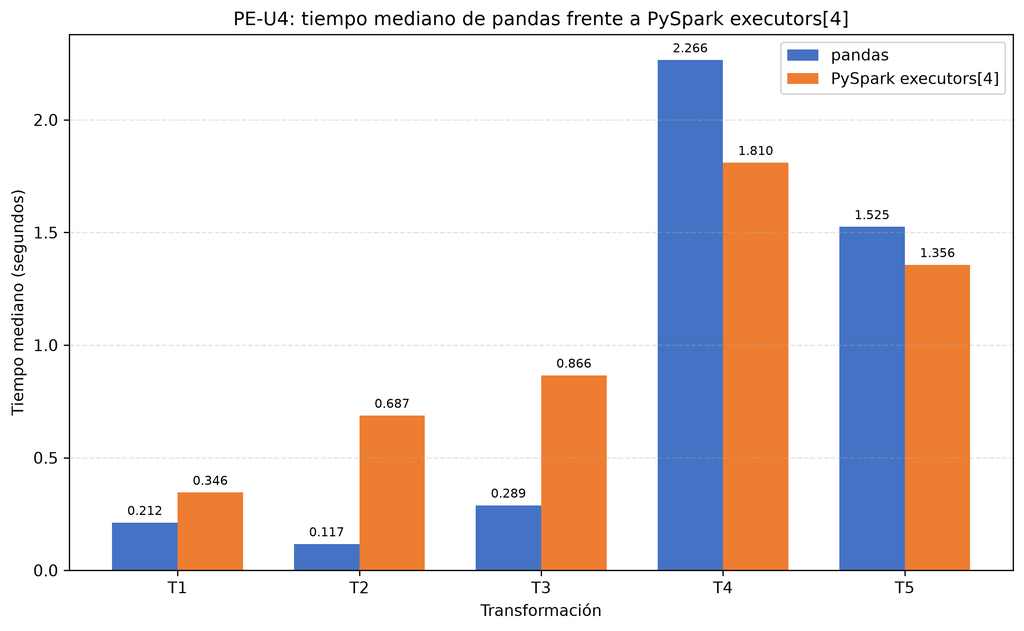

```
02_speedup_pandas_vs_pyspark.png
```

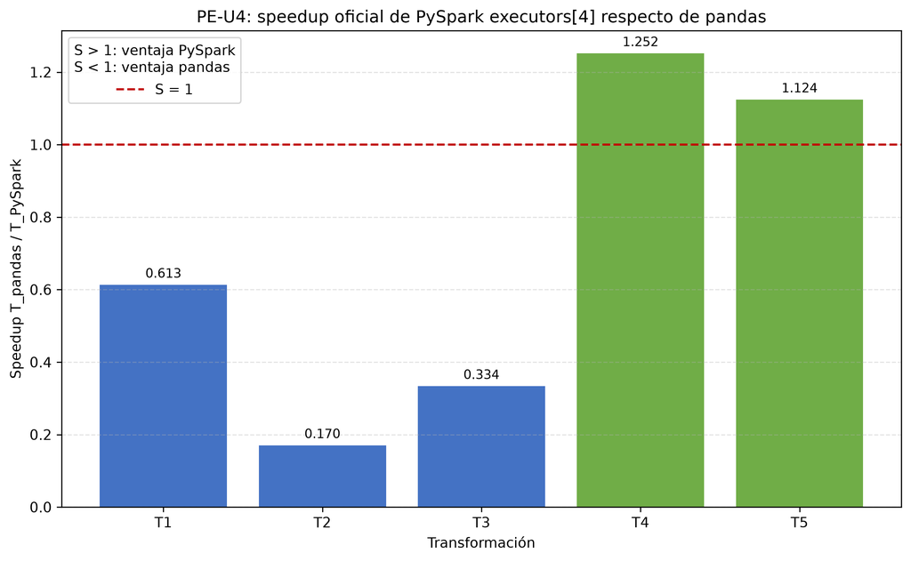

```
03_escalabilidad_t3.png
```

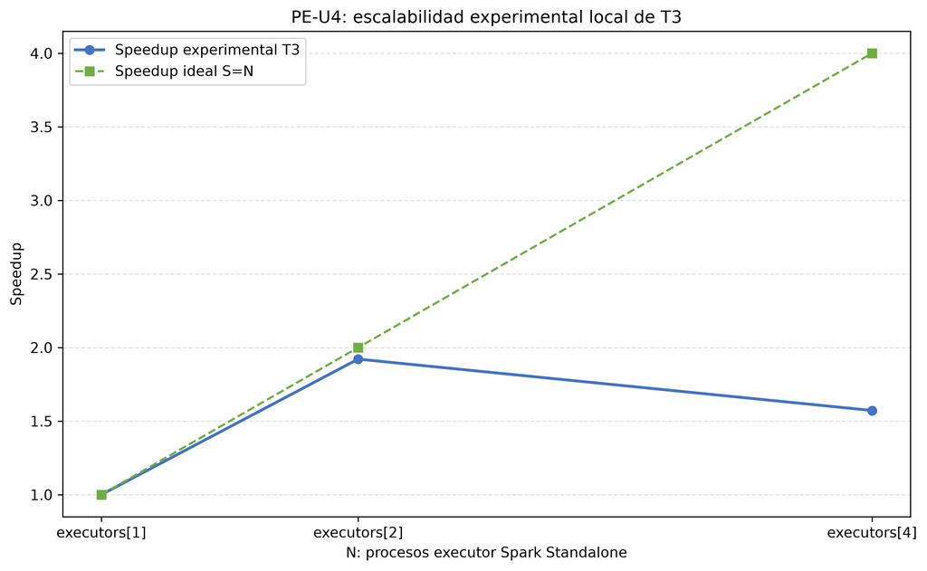

```
04_eficiencia_t3.png
```

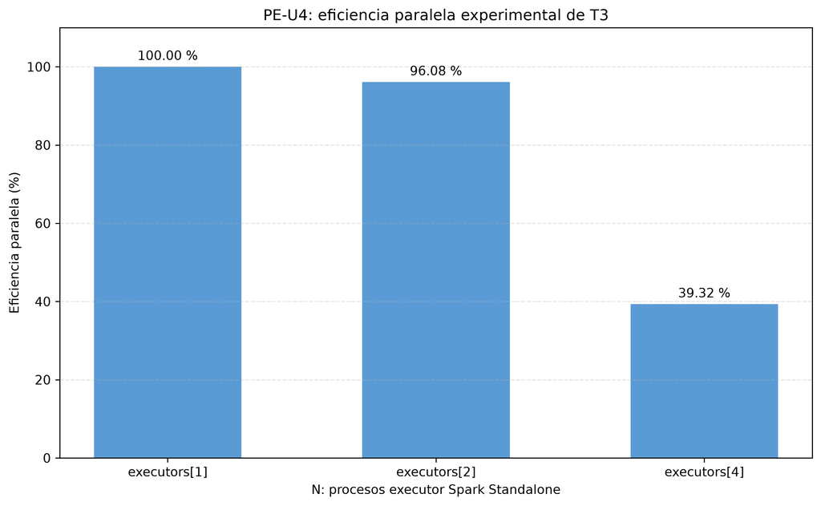

```
05_amdahl_t3.png
```

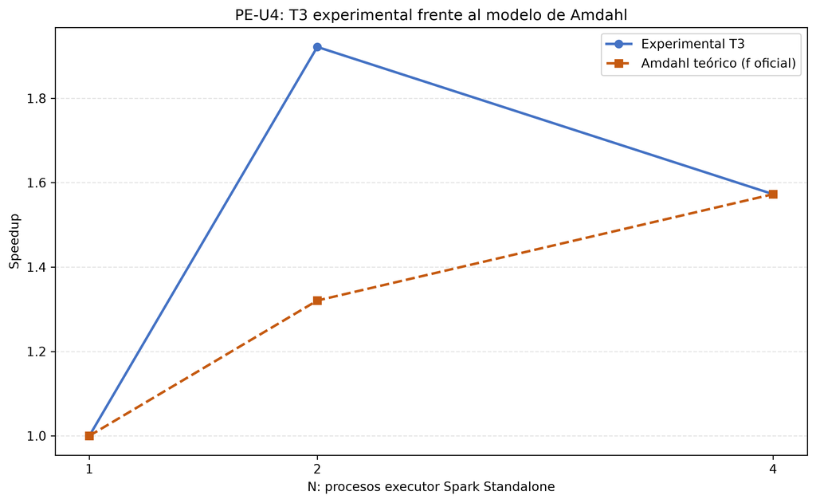

```
06_gustafson_t3.png
```

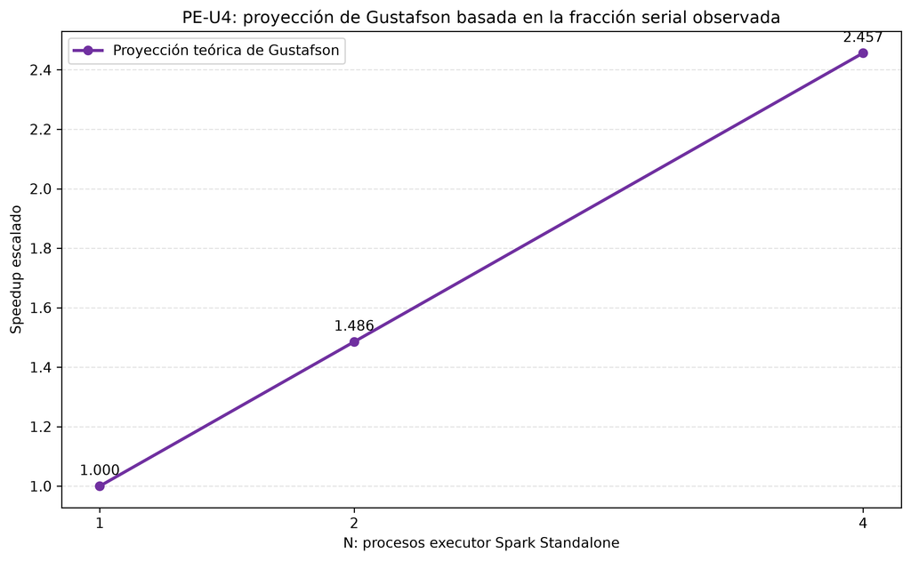

```python
figuras = [
    '01_tiempos_pandas_vs_pyspark.png',
    '02_speedup_pandas_vs_pyspark.png',
    '03_escalabilidad_t3.png',
    '04_eficiencia_t3.png',
    '05_amdahl_t3.png',
    '06_gustafson_t3.png',
]
for nombre in figuras:
    print(nombre)
    display(Image(filename=str(ROOT / 'resultados' / 'figuras' / nombre), width=850))
```